# Solutions and data exploration for Lab Report 2

```python
import pandas as pd
import seaborn as sns
import pingouin as png
```

```python
# load data for semiotics and linguistics seperately

df_sem_raw = pd.read_csv("https://raw.githubusercontent.com/ethanweed/ExPsyLing/master/datasets/Lexical-decision/2021/semiotics_2021_raw.csv")
df_ling_raw = pd.read_csv("https://raw.githubusercontent.com/ethanweed/ExPsyLing/master/datasets/Lexical-decision/2021/linguistics_2021_raw.csv")
```

```python
# add a "group" column to index semiotics and linguistics data

df_sem_raw = df_sem_raw.assign(group = ['semiotics']*df_sem_raw.shape[0])
df_ling_raw = df_ling_raw.assign(group = ['linguistics']*df_ling_raw.shape[0])

# combine semiotics and linguistics data
df = pd.concat([df_sem_raw, df_ling_raw], ignore_index=True)
```

```python
# define a function to clean up the data:
# 1. remove unnecessary columns
# 2. add a column indexing whether the answer was correct or incorrect (and make this a string, not a bool)
# 3. remove practice runs

def clean_data(df):
    df_clean = pd.DataFrame(
    {'participantID': df['jatosStudyResultId'],
     'group': df['group'],
     'block': df['block'],
     'condition': df['condition'],
     'stimulus': df['stim'],
     'correct_response': df['correct_response'],
     'response': df['response'],
     'rt': df['response_time']
    })

    # add column for correct / incorrect responses
    df_clean['correct_response'] = [x.lower() for x in list(df_clean['correct_response'])]
    correct = list(df_clean['correct_response'] == df_clean['response'])
    correct = ["correct" if x == True else "incorrect" for x in correct]
    df_clean.insert(loc = 6, column = 'correct', value = correct)


    # remove practice trials
    df_clean = df_clean[df_clean['block'] != 'practice']

    return(df_clean)
```

```python
df = clean_data(df)
df.head()
```

|  | participantID | group | block | condition | stimulus | correct_response | correct | response | rt |
| --- | --- | --- | --- | --- | --- | --- | --- | --- | --- |
| 6 | 239 | semiotics | C | Unrelated | peg-yolk | left | incorrect | right | 1543 |
| 7 | 239 | semiotics | C | Filler | afraid-scobet | right | correct | right | 2268 |
| 8 | 239 | semiotics | C | Nonword | villane-towp | right | correct | right | 1830 |
| 9 | 239 | semiotics | C | Nonword | chorch-steeble | right | incorrect | left | 1960 |
| 10 | 239 | semiotics | C | Nonword | eas-jood | right | correct | right | 1263 |

```python
df_correct = df[df['correct'] == 'correct']
```

## Solution with paired t-test

I suggeted that you analyze these data with a paired t-test, although other options are possible. I'll start with the paired t-test.

### Group the data

The first challenge is to find a mean for each participant. There are two reasons for doing this:

1. If we don't find a mean for each participant first, the t-test may think we have more participants than we really do, and this will change the degrees of freedom for the test, and this will affect what size t-value and ultimately whether or not we consider the results significant.
2. After we sort out the incorrect responses, there are no longer paired matches for every vaule in both the related and unrelated conditions. But if we find a mean for each participant, so long as they got some correct from both related and unrelated, we can compare their means in the two conditions.

We need to tell `groupby` what categories we want to use. In this case, we want a mean value for every participant in every condition, so we need to use these variables to group the data. We also need to tell grouby what we want it to calculate for each of these conditions: we want a mean, but we could also e.g. ask for a sum. The final element, reset_index just flattens everything out into a nice clean dataframe. Try it without, and you'll see what I mean.

So, to group the data, we can do

```python
data = df_correct.groupby(['participantID', 'condition']).mean().reset_index()
data.head()
```

|  | participantID | condition | rt |
| --- | --- | --- | --- |
| 0 | 226 | Filler | 992.111111 |
| 1 | 226 | Nonword | 819.333333 |
| 2 | 226 | Related | 684.894737 |
| 3 | 226 | Unrelated | 786.882353 |
| 4 | 227 | Filler | 1231.388889 |

```python
data = df_correct.groupby(['participantID', 'condition']).mean().reset_index()
```

```python
df_ttest = pd.DataFrame(
    {'unrelated': list(data.loc[data['condition'] == 'Unrelated']['rt']),
     'related': list(data.loc[data['condition'] == 'Related']['rt'])
     })

df_ttest.head()
```

|  | unrelated | related |
| --- | --- | --- |
| 0 | 786.882353 | 684.894737 |
| 1 | 969.529412 | 790.900000 |
| 2 | 933.857143 | 825.809524 |
| 3 | 987.894737 | 895.550000 |
| 4 | 1677.846154 | 1150.761905 |

### Paired t-test with scipy

So far, we have been doing t-tests with `scipy`, so let's do that first:

```python
from scipy.stats import ttest_rel

t, p = ttest_rel(df_ttest['related'],
                 df_ttest['unrelated'])
print('t =', t)
print('p =', p)
```

```
t = -7.936707585645165
p = 9.351467269046923e-08
```

### Paired t-test with pingouin

However, we could also do it with my new love, `pingouin`.

```python
import pingouin as png

png.ttest(x = df_ttest['related'],
          y = df_ttest['unrelated'],
          paired = True)
```

|  | T | dof | alternative | p-val | CI95% | cohen-d | BF10 | power |
| --- | --- | --- | --- | --- | --- | --- | --- | --- |
| T-test | -7.936708 | 21 | two-sided | 9.351467e-08 | [-288.78, -168.86] | 1.007256 | 1.595e+05 | 0.994444 |

Now, isn't that lovely? Not only do we get the same answer as with with `scipy`, but we even get a nice table that tells us the degrees of freedom, confidence intervals, and other great stuff (that we'll talk about later).

Since our data are in a "wide" format (one column per condition), `pointplot` just assumes that these two columns are the conditions we want to plot, so it is very easy to make a figure:

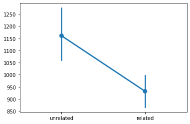

```python
sns.pointplot(data = df_ttest)
```

## Solution with ANOVA

Now, as some of you mentioned in class, these data *do* also lend themselves to an ANOVA analysis, so let's just do that to, with `pingouin`, natch.

Just like with the t-test solution above, the first thing we need to do is to group the data with `groupby`. (Actually, I think you can get away without grouping, because `pingouin` is smart enough to figure it out, but our figure will have error bars that are too small, so let's go ahead and do it anyway, just to be on the safe side). We need to tell `groupby` what categories we want to use. In this case, we want a mean value for every participant in every condition, so we need to use these variables to group the data. We also need to tell `grouby` what we want it to calculate for each of these conditions: we want a mean, but we could also e.g. ask for a sum. The final element, `reset_index` just flattens everything out into a nice clean dataframe. Try it without, and you'll see what I mean.

```python
data = df_correct.groupby(['participantID', 'condition']).mean().reset_index()
data
```

|  | participantID | condition | rt |
| --- | --- | --- | --- |
| 0 | 226 | Filler | 992.111111 |
| 1 | 226 | Nonword | 819.333333 |
| 2 | 226 | Related | 684.894737 |
| 3 | 226 | Unrelated | 786.882353 |
| 4 | 227 | Filler | 1231.388889 |
| ... | ... | ... | ... |
| 83 | 251 | Unrelated | 1190.050000 |
| 84 | 255 | Filler | 1142.105263 |
| 85 | 255 | Nonword | 1076.625000 |
| 86 | 255 | Related | 889.952381 |
| 87 | 255 | Unrelated | 1104.272727 |

88 rows × 3 columns

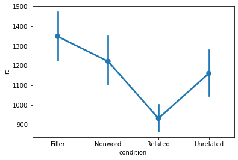

```python
ax = sns.pointplot(x = 'condition', y = 'rt', data = data)
```

`pingouin` adds ANOVA superpowers to our dataframe, so we can now call the `rm_anova` (repeated measures ANOVA) directly as a method of the dataframe:

```python
data.rm_anova(dv = 'rt', within = 'condition', subject = 'participantID')
```

|  | Source | ddof1 | ddof2 | F | p-unc | p-GG-corr | np2 | eps | sphericity | W-spher | p-spher |
| --- | --- | --- | --- | --- | --- | --- | --- | --- | --- | --- | --- |
| 0 | condition | 3 | 63 | 51.125821 | 7.157629e-17 | 5.084707e-12 | 0.708842 | 0.669414 | False | 0.346458 | 0.000859 |

Now, if we want to, we can go ahead and do "post-hoc" t-tests on our data. Here I have specified a Bonferroni correction for multiple comparisons (the very strict one that we talked about in class), but you could also specify other, less strict options, like e.g. 'holm'.

```python
data.pairwise_ttests(dv = 'rt', within = 'condition', subject = 'participantID', padjust = 'bonf')
```

|  | Contrast | A | B | Paired | Parametric | T | dof | alternative | p-unc | p-corr | p-adjust | BF10 | hedges |
| --- | --- | --- | --- | --- | --- | --- | --- | --- | --- | --- | --- | --- | --- |
| 0 | condition | Filler | Nonword | True | True | 4.938703 | 21.0 | two-sided | 6.928127e-05 | 4.156876e-04 | bonf | 381.245 | 0.398126 |
| 1 | condition | Filler | Related | True | True | 9.667500 | 21.0 | two-sided | 3.490915e-09 | 2.094549e-08 | bonf | 3.393e+06 | 1.649705 |
| 2 | condition | Filler | Unrelated | True | True | 4.809198 | 21.0 | two-sided | 9.416537e-05 | 5.649922e-04 | bonf | 289.611 | 0.624884 |
| 3 | condition | Nonword | Related | True | True | 7.250618 | 21.0 | two-sided | 3.839102e-07 | 2.303461e-06 | bonf | 4.326e+04 | 1.144875 |
| 4 | condition | Nonword | Unrelated | True | True | 2.369689 | 21.0 | two-sided | 2.746036e-02 | 1.647622e-01 | bonf | 2.165 | 0.203417 |
| 5 | condition | Related | Unrelated | True | True | -7.936708 | 21.0 | two-sided | 9.351467e-08 | 5.610880e-07 | bonf | 1.595e+05 | -0.989162 |

If no other information is available (e.g. published literature on similar tasks), we can use Cohen's rough guidelenes for interpreting effect sizes: (here, the column "hedges", which stands for Hedge’s g):

0.2 = Small effect size 0.5 = Medium effect size 0.8 = Large effect size

### Write it up

We can now write up our results, and maybe make a nicer figure with a little more inforamation, like a boxplot.

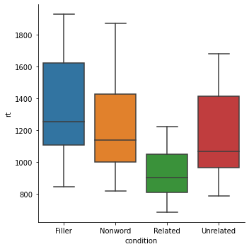

```python
ax = sns.catplot(x = 'condition', y = 'rt', kind = 'box', data = data)
```

## Other analyses

### Linguistics vs. semiotics

```python
data = df_correct.groupby(['participantID', 'condition', 'group']).mean().reset_index()
data
```

|  | participantID | condition | group | rt |
| --- | --- | --- | --- | --- |
| 0 | 226 | Filler | semiotics | 992.111111 |
| 1 | 226 | Nonword | semiotics | 819.333333 |
| 2 | 226 | Related | semiotics | 684.894737 |
| 3 | 226 | Unrelated | semiotics | 786.882353 |
| 4 | 227 | Filler | semiotics | 1231.388889 |
| ... | ... | ... | ... | ... |
| 83 | 251 | Unrelated | linguistics | 1190.050000 |
| 84 | 255 | Filler | linguistics | 1142.105263 |
| 85 | 255 | Nonword | linguistics | 1076.625000 |
| 86 | 255 | Related | linguistics | 889.952381 |
| 87 | 255 | Unrelated | linguistics | 1104.272727 |

88 rows × 4 columns

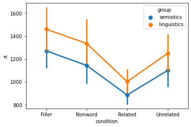

```python
ax = sns.pointplot(x = 'condition', y = 'rt', hue = 'group', data = data)
```

```python
data.mixed_anova(dv = 'rt', within = 'condition', between = 'group', subject = 'participantID')
```

|  | Source | SS | DF1 | DF2 | MS | F | p-unc | p-GG-corr | np2 | eps | sphericity | W-spher | p-spher |
| --- | --- | --- | --- | --- | --- | --- | --- | --- | --- | --- | --- | --- | --- |
| 0 | group | 5.610495e+05 | 1 | 20 | 561049.481734 | 2.298143 | 1.451754e-01 | NaN | 0.103064 | NaN | NaN | NaN | NaN |
| 1 | condition | 2.010211e+06 | 3 | 60 | 670070.372230 | 49.947075 | 2.593265e-16 | 5.084707e-12 | 0.714070 | 0.669414 | False | 0.346458 | 0.000859 |
| 2 | Interaction | 2.076046e+04 | 3 | 60 | 6920.153174 | 0.515829 | 6.729587e-01 | NaN | 0.025143 | NaN | NaN | NaN | NaN |

### Percent correct

We could also check to see if people tended to make more mistakes in any of the conditions. First, we need to find some way to calculate how many correct and incorrect scores there were in each condition. I'm going to ignore which participant made the errors for now, just to make things easier.

`crosstab` is an easy way to get the counts of correct and incorrect answers. Once we get that, we can just divide by the total number of answers to get the percent correct.

```python
data = df
data = pd.crosstab(index = data['condition'], columns = data['correct'],margins=True).reset_index()
data['percent_correct'] = data['correct'] / data['All']
data
```

| correct | condition | correct | incorrect | All | percent_correct |
| --- | --- | --- | --- | --- | --- |
| 0 | Filler | 387 | 53 | 440 | 0.879545 |
| 1 | Nonword | 393 | 17 | 410 | 0.958537 |
| 2 | Related | 437 | 11 | 448 | 0.975446 |
| 3 | Unrelated | 347 | 53 | 400 | 0.867500 |
| 4 | All | 1564 | 134 | 1698 | 0.921084 |

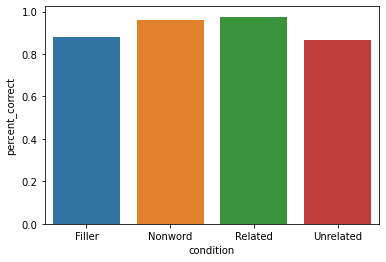

```python
data = data[data['condition'] != 'All']
sns.barplot(x = 'condition', y = 'percent_correct', data = data)
```

### Individual items

We could also scan the data to see if there are any individual stimulus pairs that gave people particular trouble. Of course, we can't read which pairs are which in the figures below, but it gives us an idea of the distribution.

```python
data = df_correct.groupby(['stimulus', 'condition', 'group']).mean().reset_index()
data.head()
```

|  | stimulus | condition | group | participantID | rt |
| --- | --- | --- | --- | --- | --- |
| 0 | ace-snow | Unrelated | linguistics | 249.50 | 963.000000 |
| 1 | ace-snow | Unrelated | semiotics | 233.00 | 1230.400000 |
| 2 | add-subtract | Related | linguistics | 247.00 | 1018.666667 |
| 3 | add-subtract | Related | semiotics | 232.75 | 1101.750000 |
| 4 | afraid-scobet | Filler | linguistics | 248.75 | 1790.875000 |

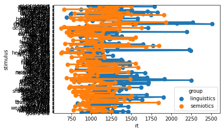

```python
sns.pointplot(x = 'rt', y = 'stimulus', hue = 'group', data = data)
```

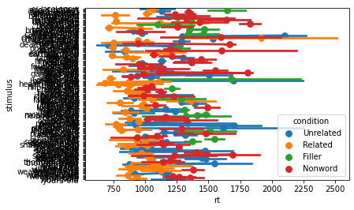

```python
sns.pointplot(x = 'rt', y = 'stimulus', hue = 'condition', data = data)
```

### stimuli with the longest response time

```python
sorted_df = df_correct.sort_values(by='rt', ascending = False)
sorted_df
```

|  | participantID | group | block | condition | stimulus | correct_response | correct | response | rt |
| --- | --- | --- | --- | --- | --- | --- | --- | --- | --- |
| 1808 | 243 | linguistics | A | Unrelated | carves-round | left | correct | left | 3481 |
| 28 | 239 | semiotics | C | Unrelated | mood-star | left | correct | left | 3305 |
| 1244 | 251 | linguistics | C | Filler | afraid-scobet | right | correct | right | 3289 |
| 1813 | 243 | linguistics | A | Filler | green-gliss | right | correct | right | 3124 |
| 729 | 231 | semiotics | A | Filler | neibon-thread | right | correct | right | 3092 |
| ... | ... | ... | ... | ... | ... | ... | ... | ... | ... |
| 994 | 227 | semiotics | C | Unrelated | mood-star | left | correct | left | 516 |
| 1083 | 226 | semiotics | B | Related | dark-night | left | correct | left | 490 |
| 399 | 235 | semiotics | B | Related | hard-soft | left | correct | left | 479 |
| 975 | 227 | semiotics | C | Unrelated | gain-hurt | left | correct | left | 435 |
| 1001 | 227 | semiotics | C | Related | baby-child | left | correct | left | 421 |

1564 rows × 9 columns

### stimuli with the fastest response times

```python
sorted_df = df_correct.sort_values(by='rt', ascending = True)
sorted_df
```

|  | participantID | group | block | condition | stimulus | correct_response | correct | response | rt |
| --- | --- | --- | --- | --- | --- | --- | --- | --- | --- |
| 1001 | 227 | semiotics | C | Related | baby-child | left | correct | left | 421 |
| 975 | 227 | semiotics | C | Unrelated | gain-hurt | left | correct | left | 435 |
| 399 | 235 | semiotics | B | Related | hard-soft | left | correct | left | 479 |
| 1083 | 226 | semiotics | B | Related | dark-night | left | correct | left | 490 |
| 994 | 227 | semiotics | C | Unrelated | mood-star | left | correct | left | 516 |
| ... | ... | ... | ... | ... | ... | ... | ... | ... | ... |
| 729 | 231 | semiotics | A | Filler | neibon-thread | right | correct | right | 3092 |
| 1813 | 243 | linguistics | A | Filler | green-gliss | right | correct | right | 3124 |
| 1244 | 251 | linguistics | C | Filler | afraid-scobet | right | correct | right | 3289 |
| 28 | 239 | semiotics | C | Unrelated | mood-star | left | correct | left | 3305 |
| 1808 | 243 | linguistics | A | Unrelated | carves-round | left | correct | left | 3481 |

1564 rows × 9 columns

### Does the semiotics or linguistics group have more variation?

```python
lin = pd.DataFrame(data[data['group'] == 'linguistics']['rt'].describe()).reset_index()
sem = pd.DataFrame(data[data['group'] == 'semiotics']['rt'].describe()).reset_index()
```

```python
combined = lin.merge(sem, on = 'index')
combined
```

|  | index | rt_x | rt_y |
| --- | --- | --- | --- |
| 0 | count | 192.000000 | 192.000000 |
| 1 | mean | 1226.250719 | 1068.240034 |
| 2 | std | 327.208203 | 266.688219 |
| 3 | min | 692.666667 | 621.000000 |
| 4 | 25% | 990.166667 | 874.375000 |
| 5 | 50% | 1157.666667 | 1008.300000 |
| 6 | 75% | 1372.187500 | 1252.312500 |
| 7 | max | 2512.000000 | 1930.500000 |

```python
combined = combined[combined['index'] == 'std']
combined.rename(columns = {'rt_x':'linguistics', 'rt_y':'semiotics'}, inplace = True)
combined = pd.melt(combined, value_vars=['linguistics', 'semiotics'])
combined.rename(columns = {'variable':'group', 'value':'sd'}, inplace = True)
combined
```

|  | group | sd |
| --- | --- | --- |
| 0 | linguistics | 327.208203 |
| 1 | semiotics | 266.688219 |

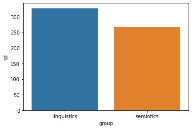

```python
sns.barplot(x = 'group', y = 'sd', data = combined)
```